# Overview

```r
library(ggplot2)
library(reshape)
library(gplots)
library(edgeR)
library(CHBUtils)
library(pheatmap)
library(DESeq2)
project_summary = "~/R/harwell_prdm16/meta/project-summary.csv"
counts_file = "~/R/harwell_prdm16/data/combined.counts"
meta = "~/R/harwell_prdm16/meta/project.csv"
cbPalette <- c("#999999", "#E69F00", "#56B4E9", "#009E73", "#F0E442", "#0072B2",
    "#D55E00", "#CC79A7")
summarydata = data.frame(read.table(project_summary, header = TRUE, sep = ","),
    row.names = "Name", check.rows = FALSE)
summarydata$Name = rownames(summarydata)
summarydata = summarydata[order(summarydata$Name), ]
counts = read.table(counts_file, header = TRUE, row.names = "id", check.names = FALSE)
counts = counts[, order(colnames(counts))]
colnames(counts) = gsub(".counts", "", colnames(counts))
# this is a list of all non user-supplied metadata columns that could appear
known_columns = c("Name", "X.GC", "Exonic.Rate", "Sequences.flagged.as.poor.quality",
    "rRNA_rate", "Fragment.Length.Mean", "Intronic.Rate", "Intergenic.Rate",
    "Mapping.Rate", "Quality.format", "Duplication.Rate.of.Mapped", "Mapped",
    "rRNA", "Sequence.length", "Transcripts.Detected", "Mean.Per.Base.Cov.",
    "Genes.Detected", "Unique.Starts.Per.Read", "unique_starts_per_read", "complexity",
    "X5.3.bias", "Duplicates.pct", "Duplicates", "Mapped.reads", "Median.insert.size",
    "Mapped.reads.pct", "Total.reads", "avg_coverage_per_region")

# Add shortname
summarydata$Name <- gsub("LIB018752_", "", row.names(summarydata))
row.names(summarydata) <- summarydata$Name
colnames(counts) <- summarydata$Name
```

```r
get_heatmap_fn = function(summarydata) {
    # return the pheatmap function with or without metadata
    metadata = summarydata[, !colnames(summarydata) %in% known_columns, drop = FALSE]
    if (ncol(metadata) == 0) {
        return(pheatmap)
    } else {
        # rownames(metadata) = summarydata$Name
        heatmap_fn = function(data, ...) {
            pheatmap(data, annotation = metadata, ...)
        }
        return(heatmap_fn)
    }
}
heatmap_fn = get_heatmap_fn(summarydata)
```

# Quality control metrics

## Mapped reads

For all samples, there is > 10 million reads, with some samples having libraries on the larger end (~20 million).

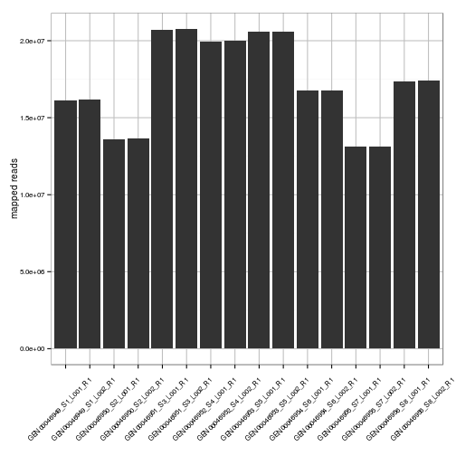

```r
ggplot(summarydata, aes(x = Name, y = Mapped)) + theme_bw(base_size = 10) +
    theme(panel.grid.major = element_line(size = 0.5, color = "grey"), axis.text.x = element_text(angle = 45,
        vjust = 0.5, hjust = 0.6)) + geom_bar(stat = "identity") + ylab("mapped reads") +
    xlab("")
```

## Genomic mapping rate

Very high mapping rate across the board for samples.

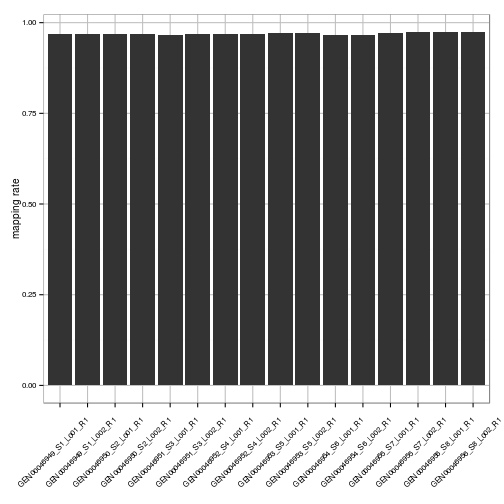

```r
ggplot(summarydata, aes(x = Name, y = Mapping.Rate)) + geom_bar(stat = "identity") +
    ylab("mapping rate") + xlab("") + theme_bw(base_size = 10) + theme(panel.grid.major = element_line(size = 0.5,
    color = "grey"), axis.text.x = element_text(angle = 45, vjust = 0.5, hjust = 0.6))
```

## Number of genes detected

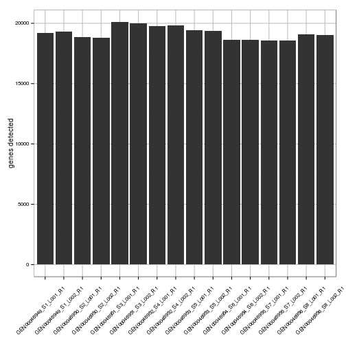

```r
dd = data.frame(Name = names(counts), Genes.Detected = colSums(counts > 0))
ggplot(dd, aes(x = Name, y = Genes.Detected)) + geom_bar(stat = "identity") +
    theme_bw(base_size = 10) + theme(panel.grid.major = element_line(size = 0.5,
    color = "grey"), axis.text.x = element_text(angle = 45, vjust = 0.5, hjust = 0.6)) +
    ylab("genes detected") + xlab("")
```

## Gene detection saturation

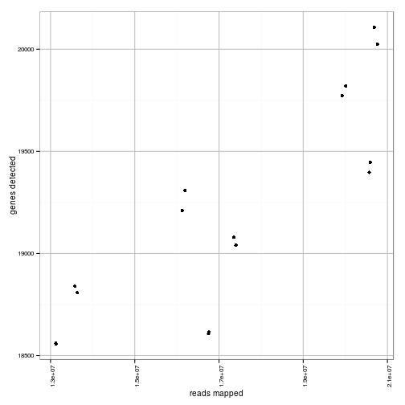

```r
dd = data.frame(Mapped = summarydata$Mapped, Genes.Detected = colSums(counts >
    0))
ggplot(dd, aes(x = Mapped, y = Genes.Detected)) + geom_point() + theme_bw(base_size = 10) +
    theme(panel.grid.major = element_line(size = 0.5, color = "grey"), axis.text.x = element_text(angle = 90)) +
    ylab("genes detected") + xlab("reads mapped")
```

## Mapping location

The next two figures gives us insight as to where reads are mapping. There are an unusually low number of reads mapping to exonic regions (~30%) and higher than normally observed mapping to intronic regions (~60%; see below). This may be due to a variety of reasons. It could be driven by genomic DNA contamination and/or unprocessed RNA. Or it is possible that these map to nascent RNAs, i.e. genes that are being transcribed but where the polymerase has not yet reached the end of the gene. Another possibiity is due to unannotated exons and genuine splicing events.

## Exonic mapping rate

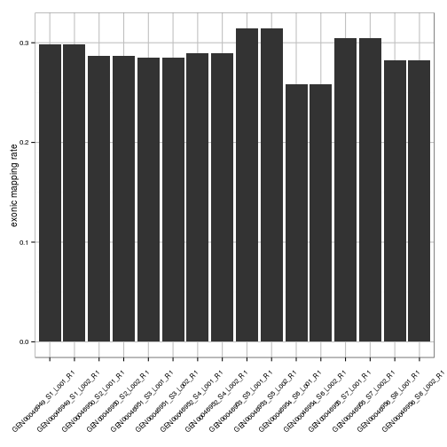

```r
ggplot(summarydata, aes(x = Name, y = Exonic.Rate)) + geom_bar(stat = "identity") +
    theme_bw(base_size = 10) + theme(panel.grid.major = element_line(size = 0.5,
    color = "grey"), axis.text.x = element_text(angle = 45, vjust = 0.5, hjust = 0.6)) +
    ylab("exonic mapping rate") + xlab("")
```

## Intronic mapping rate

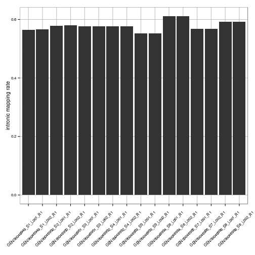

```r
ggplot(summarydata, aes(x = Name, y = Intronic.Rate)) + geom_bar(stat = "identity") +
    theme_bw(base_size = 10) + theme(panel.grid.major = element_line(size = 0.5,
    color = "grey"), axis.text.x = element_text(angle = 45, vjust = 0.5, hjust = 0.6)) +
    ylab("intronic mapping rate") + xlab("")
```

## rRNA mapping rate

Ribsomal gene levels are high but not unusual if a ribo-depletion protocol was applied.

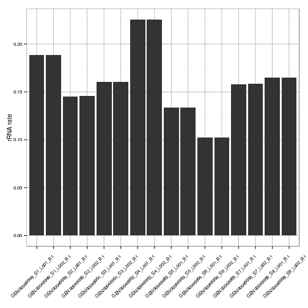

```r
ggplot(summarydata, aes(x = Name, y = rRNA_rate)) + geom_bar(stat = "identity") +
    theme_bw(base_size = 10) + theme(panel.grid.major = element_line(size = 0.5,
    color = "grey"), axis.text.x = element_text(angle = 45, vjust = 0.5, hjust = 0.6)) +
    ylab("rRNA rate") + xlab("")
```

Expression levels are fairly consistent across samples, whether we look at counts or normalized data.

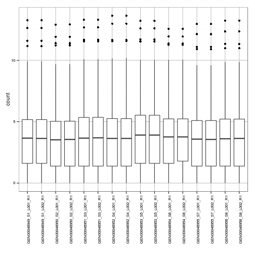

```r
melted = melt(counts)
colnames(melted) = c("sample", "count")
melted$sample = factor(melted$sample)
melted = melted[order(melted$sample), ]
melted$count = log(melted$count)
ggplot(melted, aes(x = sample, y = count)) + geom_boxplot() + theme_bw(base_size = 10) +
    theme(panel.grid.major = element_line(size = 0.5, color = "grey"), axis.text.x = element_text(angle = 90)) +
    xlab("")
```

Trimmed mean of M-values (TMM) normalization is described [here](http://genomebiology.com/2010/11/3/R25)

Robinson, M. D., & Oshlack, A. (2010). A scaling normalization method for differential expression analysis of RNA-seq data. Genome Biology, 11(3). doi:10.1186/gb-2010-11-3-r25

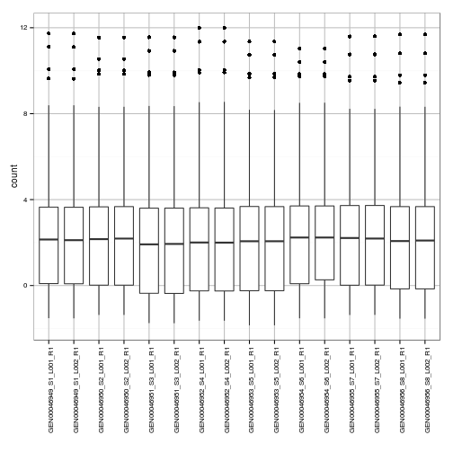

```r
y = DGEList(counts = counts)
y = calcNormFactors(y)
normalized_counts = cpm(y, normalized.lib.sizes = TRUE)
melted = melt(normalized_counts)
colnames(melted) = c("gene", "sample", "count")
melted$sample = factor(melted$sample)
melted = melted[order(melted$sample), ]
melted$count = log(melted$count)
ggplot(melted, aes(x = sample, y = count)) + geom_boxplot() + theme_bw(base_size = 10) +
    theme(panel.grid.major = element_line(size = 0.5, color = "grey"), axis.text.x = element_text(angle = 90)) +
    xlab("")
```

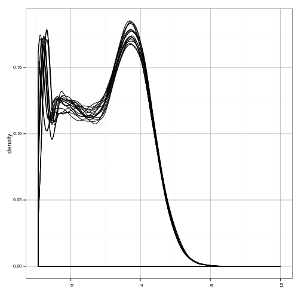

```r
ggplot(melted, aes(x = count, group = sample)) + geom_density() + theme_bw(base_size = 10) +
    theme(panel.grid.major = element_line(size = 0.5, color = "grey"), axis.text.x = element_text(angle = 90)) +
    xlab("")
```

## Correlation (Pearson) heatmap of TMM-normalized counts

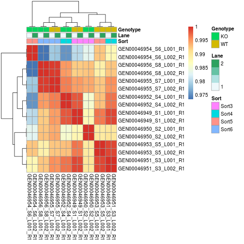

```r
heatmap_fn(cor(normalized_counts, method = "pearson"))
```

## Correlation (Spearman) heatmap of TMM-normalized counts

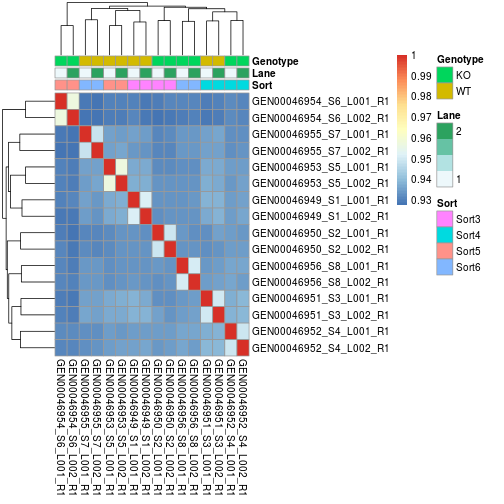

```r
heatmap_fn(cor(normalized_counts, method = "spearman"))
```

## PCA plot

Similar to the correlation plots we see samples from the same sort separating. However, what is encouraging to see is that with PC1, where 61% of the variance is explained, the samples segregate by genotype.

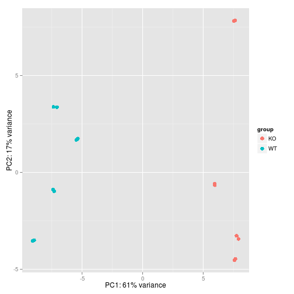

```r
dds = DESeqDataSetFromMatrix(countData = counts, colData = summarydata, design = ~Name)
vst = varianceStabilizingTransformation(dds)
plotPCA(vst, intgroup = c("Genotype"))
```

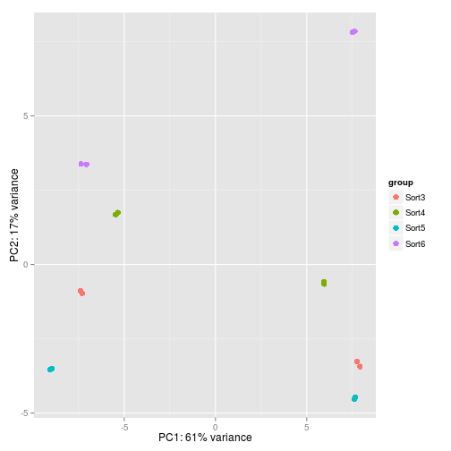

```r
plotPCA(vst, intgroup = c("Sort"))
```

Styled with knitrBootstrap